# Final Presentation: Predicting Housing Prices

December 10, 2018

## Dataset

- Predicting Housing Prices
- 1460 Observations
- 81 variables
- 20 Chosen
  - Rooms
  - Quality
  - Condition
  - Target
    - Median U.S. House Value ($192,000)
- Kaggle

## Balance of the Target Variable

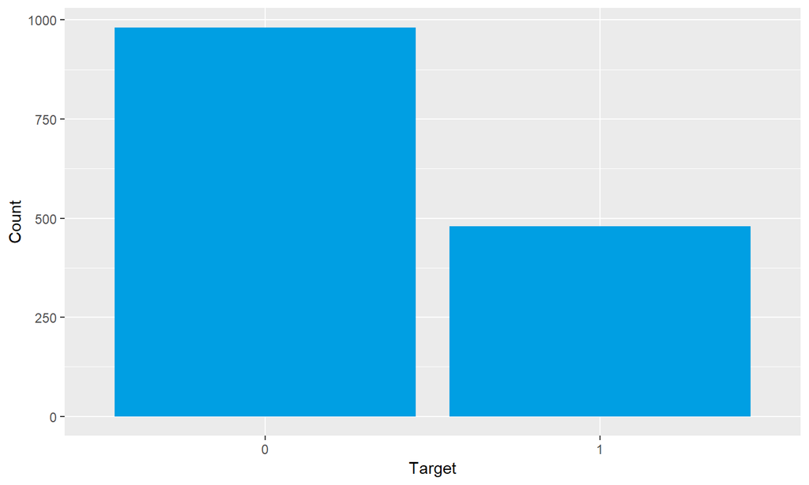

- 67.19% of the observations fall below the median housing price in the US.

## Quality of the Construction

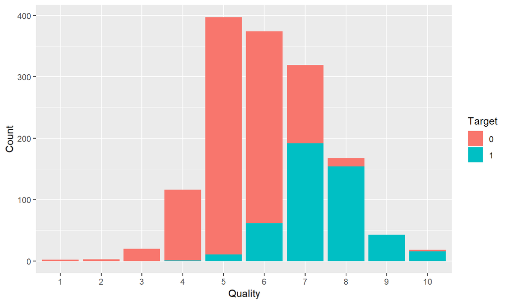

- Higher quality homes tend to be more expensive and vice versa.

## Garage Type

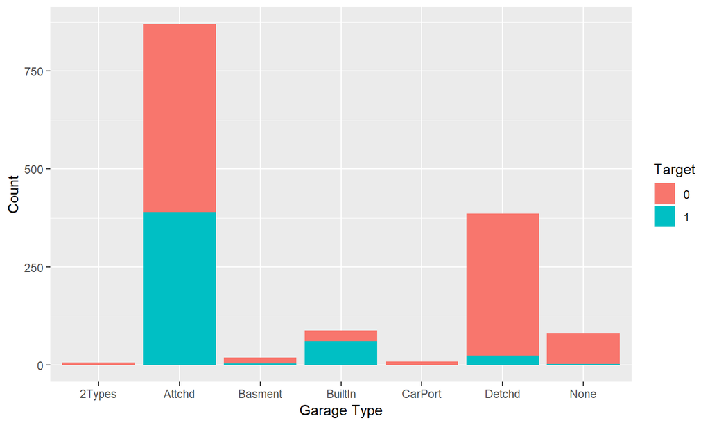

- Expensive: Attached or Built-in
- Cheap: Detached or None

## Garage Cars

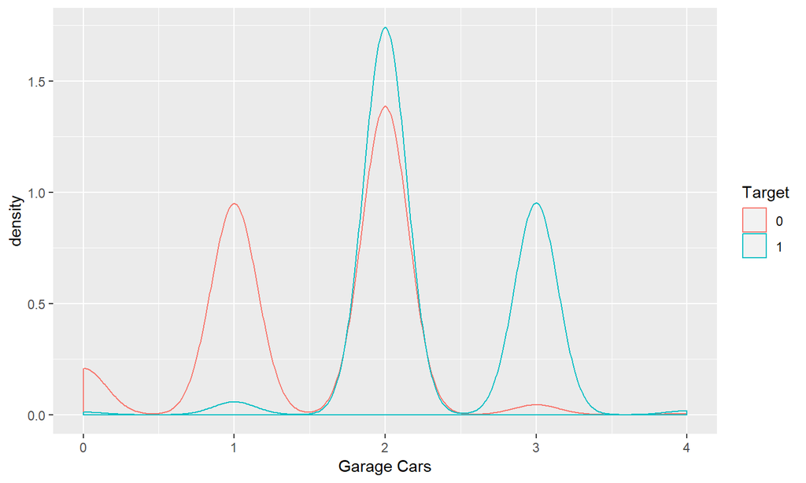

- Expensive: 3
- Cheap: 0 or 1

## Sale Condition

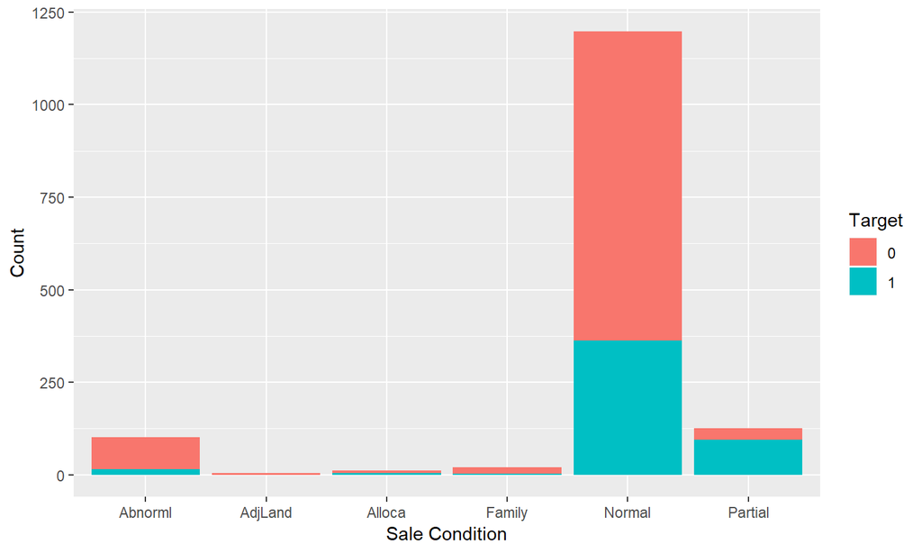

- Expensive: Partial (Incomplete Construction)
- Cheap: Abnormal (Foreclosure, etc) or Normal

## Year of Construction

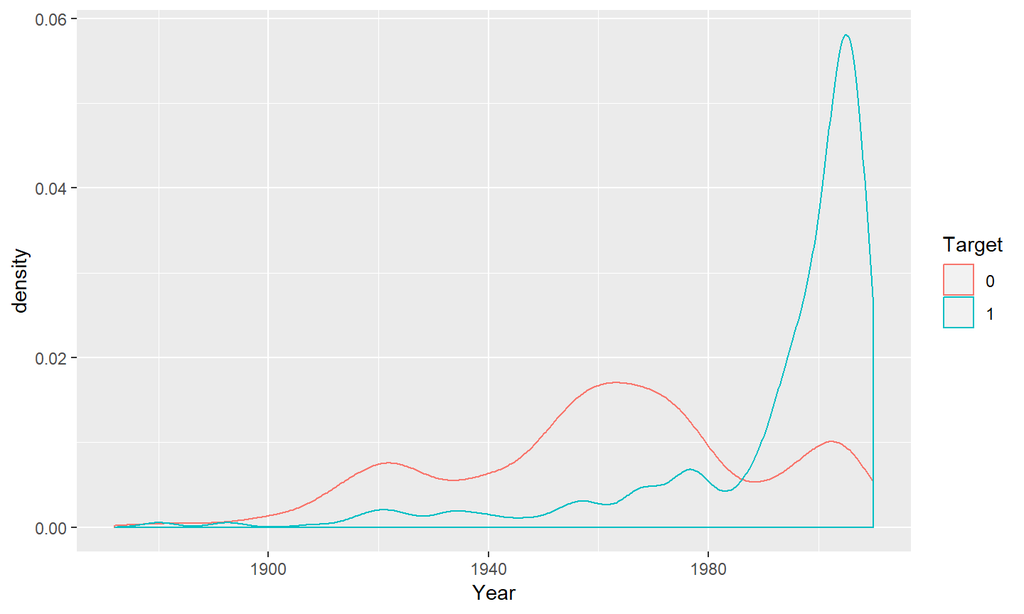

## Living Area

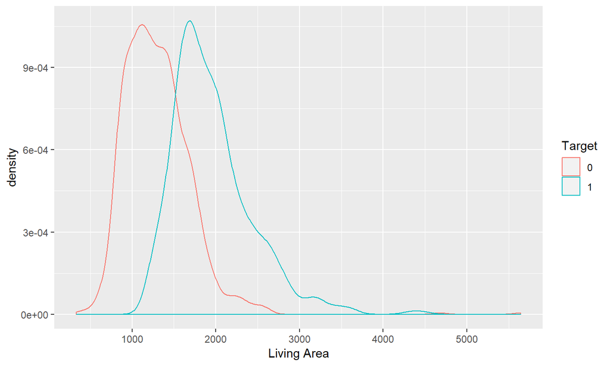

## Full Bathrooms

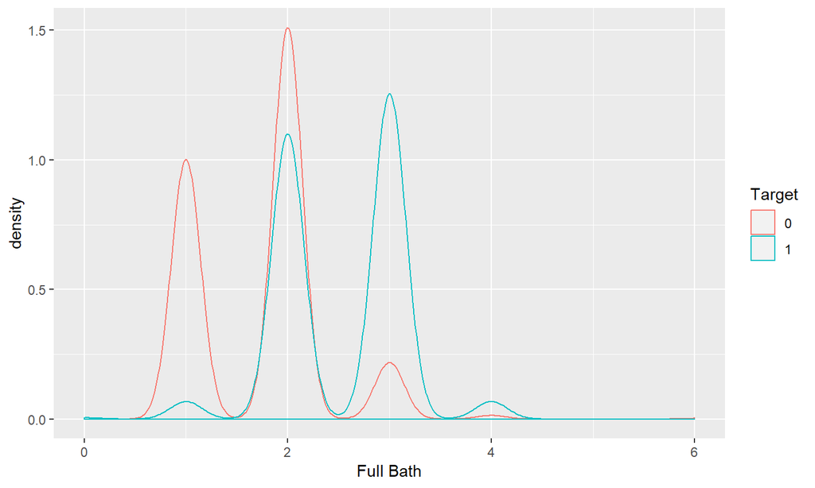

- Expensive: 3
- Cheap: 1

## Rooms

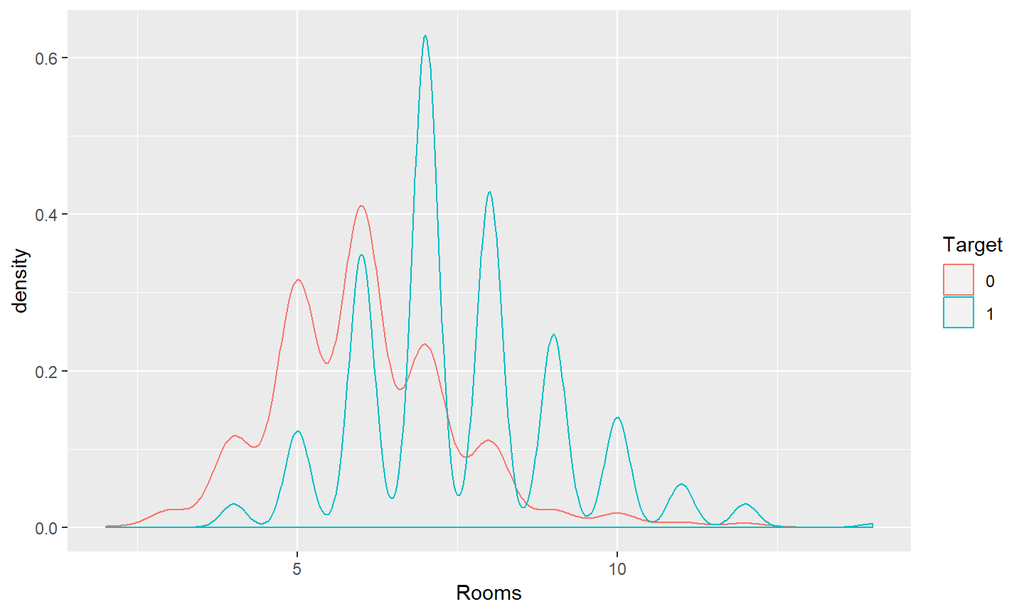

## Missing Values

- Lot Frontage: 259 missing

```
##         Average BA
## Mean      0.880288
## Median    0.881500
## Removed   0.892419
```

- Effect is minimal, as expected.
- Removal method has best results.

## Encoding/Recoding Categorical

```
##                    Average BA
## None                 0.881245
## Dummy Encoding       0.879392
## Numerical Encoding   0.892417
## Recoding             0.885708
```

- Numerical Encoding gave best average result.
- Dummy Encoding decreased the effectiveness of the models, on average.
- Recoding showed a moderate improvement.

## Models

- Four Types of Models

```
##               Average BA
## Decision Tree   0.844092
## Random Forest   0.901933
## Glmnet          0.905075
## Logistic        0.887842
```

- Glmnet: the highest average.
- Decision Tree: the lowest average.

## Full Results

```
##                       Tree   Forest   Glmnet Logistic Average BA
## Mean              0.854100 0.915000 0.911700 0.887500   0.892075
## Median            0.829500 0.899100 0.878500 0.869700   0.869200
## Removed           0.834700 0.912500 0.907300 0.877500   0.883000
## Mean Dummy        0.857400 0.892400 0.881800 0.871300   0.875725
## Mean Numerical    0.826100 0.876700 0.890700 0.888900   0.870600
## Mean Recoding     0.824300 0.909600 0.899300 0.897800   0.882750
## Median Dummy      0.834800 0.881900 0.938000 0.864300   0.879750
## Median Numerical  0.853900 0.918800 0.918800 0.922300   0.903450
## Median Recoding   0.840200 0.884000 0.889400 0.880800   0.873600
## Removed Dummy     0.853600 0.904600 0.909900 0.862700   0.882700
## Removed Numerical 0.862300 0.917400 0.917600 0.915500   0.903200
## Removed Recoded   0.858200 0.911200 0.917900 0.915800   0.900775
## Average BA        0.844092 0.901933 0.905075 0.887842   0.000000
```

## Results Analysis

```
##        Tree Forest Glmnet Logistic
## First     0      5      6        1
## Second    0      5      5        2
## Third     0      2      1        9
## Fourth   12      0      0        0
```

- Decision Tree always worst.
- Glmnet and Forest both perform well

## Best Models

```
##                           Balanced Accuracy
## Median Dummy Glmnet                  0.9380
## Median Numerical Logistic            0.9223
## Median Numerical Glmnet              0.9188
## Median Numerical Forest              0.9188
```

- Median method dominates, though it wasn't the best on average.
- Numerical Encoding remains high performing.
- Dummy Encoded produced the best model, though it was the worst on average.

## Tuning

```
##                           Originial BA Tuned BA
## Median Dummy Glmnet             0.9380   0.8805
## Median Numerical Logistic       0.9223   0.9223
## Median Numerical Glmnet         0.9188   0.9188
## Median Numerical Forest         0.9188   0.9188
```

- Tuning did not increase the performance of the models.
- Median Dummy Glmnet decreased performance.
- All others remained the same.

## Best Model

```
##             Model  Imputation Encoding Balanced Accuracy
## Final Model Glmnet Median     Dummy    .9380
```